# Deep_Neural_Network_Bank_Churn_Prediction

### Model Building

```python
#Fixing the seed for random number generators so that we can ensure we receive the same output everytime
import random
backend.clear_session()
np.random.seed(1)
random.seed(1)
tf.random.set_seed(1)
```

The first model that we will attempt will only feature 3 layers total: an input, a hidden layer, and an output. No dropout or batch normalization will be applied. This will be considered the baseline performance that we will try to improve upon.

```python
# Initializing the model
model_0 = Sequential()
model_0.add(Dense(64, activation='relu', input_dim=x_train.shape[1]))
model_0.add(Dense(32, activation='relu'))
model_0.add(Dense(1, activation='sigmoid'))

# Compliling the model with binary crossentropy as loss, SGD as optimizer and recall as metric
model_0.compile(loss = 'binary_crossentropy', optimizer = 'SGD', metrics = tf.keras.metrics.Recall())
# Printing the summary of the model
model_0.summary()
```

```
Model: "sequential"
_________________________________________________________________
 Layer (type)                Output Shape              Param #
=================================================================
 dense (Dense)               (None, 64)                640

 dense_1 (Dense)             (None, 32)                2080

 dense_2 (Dense)             (None, 1)                 33

=================================================================
Total params: 2,753
Trainable params: 2,753
Non-trainable params: 0
_________________________________________________________________
```

```python
# Defining Early Stopping
es_cb = callbacks.EarlyStopping(monitor='val_loss',
                                min_delta=0.001,
                                patience=10)

# Fitting the model on train data
history_0 = model_0.fit(x_train,
                        y_train,
                        validation_data = (x_val, y_val),
                        epochs = 100,
                        callbacks = es_cb,
                        verbose = 0)
```

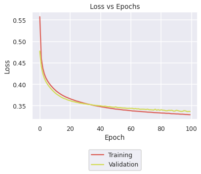

```python
# Visualizing the loss versus epoch for validation and training data sets
plt.plot(history_0.history['loss'])
plt.plot(history_0.history['val_loss'])
plt.title('Loss vs Epochs')
plt.ylabel('Loss')
plt.xlabel('Epoch')
plt.legend(['Training', 'Validation'], loc = 'lower center',  bbox_to_anchor=(0.5, -0.5))
plt.show()
```

The model appears to be correctly fit and generalizing well

```python
def make_confusion_matrix(cf,
                          group_names=None,
                          categories='auto',
                          count=True,
                          percent=True,
                          cbar=True,
                          xyticks=True,
                          xyplotlabels=True,
                          sum_stats=True,
                          figsize=None,
                          cmap='Blues',
                          title=None):
    '''
    This function will make a pretty plot of an sklearn Confusion Matrix cm using a Seaborn heatmap visualization.
    Arguments
    '''

    # CODE TO GENERATE TEXT INSIDE EACH SQUARE
    blanks = ['' for i in range(cf.size)]

    if group_names and len(group_names)==cf.size:
        group_labels = ["{}\n".format(value) for value in group_names]
    else:
        group_labels = blanks

    if count:
        group_counts = ["{0:0.0f}\n".format(value) for value in cf.flatten()]
    else:
        group_counts = blanks

    if percent:
        group_percentages = ["{0:.2%}".format(value) for value in cf.flatten()/np.sum(cf)]
    else:
        group_percentages = blanks

    box_labels = [f"{v1}{v2}{v3}".strip() for v1, v2, v3 in zip(group_labels,group_counts,group_percentages)]
    box_labels = np.asarray(box_labels).reshape(cf.shape[0],cf.shape[1])

    # CODE TO GENERATE SUMMARY STATISTICS & TEXT FOR SUMMARY STATS
    if sum_stats:
        #Accuracy is sum of diagonal divided by total observations
        accuracy  = np.trace(cf) / float(np.sum(cf))

    # SET FIGURE PARAMETERS ACCORDING TO OTHER ARGUMENTS
    if figsize==None:
        #Get default figure size if not set
        figsize = plt.rcParams.get('figure.figsize')

    if xyticks==False:
        #Do not show categories if xyticks is False
        categories=False

    # MAKE THE HEATMAP VISUALIZATION
    plt.figure(figsize=figsize)
    sns.heatmap(cf,annot=box_labels,fmt="",cmap=cmap,cbar=cbar,xticklabels=categories,yticklabels=categories)


    if title:
        plt.title(title)
```

```
Training Data Confusion Matrix:
```

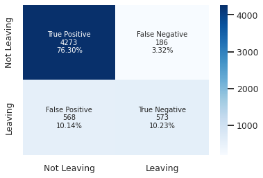

```python
# Setting the prediction threshold
y_pred=model_0.predict(x_train)
y_pred = (y_pred > 0.5)
#Calculating the confusion matrix
cm=confusion_matrix(y_train, y_pred)
labels = ['True Positive','False Negative','False Positive','True Negative']
categories = [ 'Not Leaving','Leaving']
make_confusion_matrix(cm,
                      group_names=labels,
                      categories=categories,
                      cmap='Blues')
print('Training Data Confusion Matrix:')
```

```python
# Viewing the training classification report
cr=metrics.classification_report(y_train,y_pred)
print('Training Data Classification Report:')
print(cr)
```

```
Training Data Classification Report:
              precision    recall  f1-score   support

           0       0.88      0.96      0.92      4459
           1       0.75      0.50      0.60      1141

    accuracy                           0.87      5600
   macro avg       0.82      0.73      0.76      5600
weighted avg       0.86      0.87      0.85      5600
```

Recall on the predicted class is quite poor for the training data set.

```
Validation Data Confusion Matrix:
```

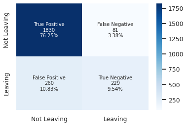

```python
# Setting the prediction threshold
y_pred=model_0.predict(x_val)
y_pred = (y_pred > 0.5)
#Calculating the confusion matrix
cm=confusion_matrix(y_val, y_pred)
labels = ['True Positive','False Negative','False Positive','True Negative']
categories = [ 'Not Leaving','Leaving']
make_confusion_matrix(cm,
                      group_names=labels,
                      categories=categories,
                      cmap='Blues')
print('Validation Data Confusion Matrix:')
```

```python
# Viewing the validation classification report
cr=metrics.classification_report(y_val,y_pred)
print('Validation Data Classification Report:')
print(cr)
```

```
Validation Data Classification Report:
              precision    recall  f1-score   support

           0       0.88      0.96      0.91      1911
           1       0.74      0.47      0.57       489

    accuracy                           0.86      2400
   macro avg       0.81      0.71      0.74      2400
weighted avg       0.85      0.86      0.85      2400
```

The validation data set also features poor recall on the predicted class. Lets see if we can improve this by changing the threshold via ROC-AUC curves.

```
Best Threshold=0.217609, G-Mean=0.787
```

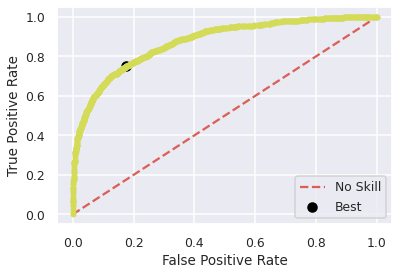

```python
# predict probabilities
yhat0 = model_0.predict(x_train)
# keep probabilities for the positive outcome only
yhat0 = yhat0[:, 0]
# calculate roc curves
fpr, tpr, thresholds0 = roc_curve(y_train, yhat0)
# calculate the g-mean for each threshold
gmeans0 = np.sqrt(tpr * (1-fpr))
# locate the index of the largest g-mean
ix = np.argmax(gmeans0)
print('Best Threshold=%f, G-Mean=%.3f' % (thresholds0[ix], gmeans0[ix]))
# plot the roc curve for the model
pyplot.plot([0,1], [0,1], linestyle='--', label='No Skill')
pyplot.plot(fpr, tpr, marker='.')
pyplot.scatter(fpr[ix], tpr[ix], marker='o', color='black', label='Best')
# axis labels
pyplot.xlabel('False Positive Rate')
pyplot.ylabel('True Positive Rate')
pyplot.legend()
# show the plot
pyplot.show()
```

```
Training Data Confusion Matrix (Optimal Threshold):
```

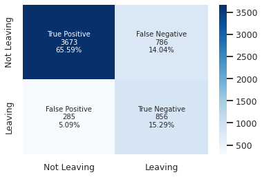

```python
# Setting the prediction threshold
y_pred = model_0.predict(x_train)
y_pred = (y_pred > thresholds0[ix])
#Calculating the confusion matrix
cm=confusion_matrix(y_train, y_pred)
labels = ['True Positive','False Negative','False Positive','True Negative']
categories = [ 'Not Leaving','Leaving']
make_confusion_matrix(cm,
                      group_names=labels,
                      categories=categories,
                      cmap='Blues')
print('Training Data Confusion Matrix (Optimal Threshold):')
```

```python
# Viewing the training classification report
cr=metrics.classification_report(y_train,y_pred)
print('Training Data Classification Report (Optimal Threshold):')
print(cr)
```

```
Training Data Classification Report (Optimal Threshold):
              precision    recall  f1-score   support

           0       0.93      0.82      0.87      4459
           1       0.52      0.75      0.62      1141

    accuracy                           0.81      5600
   macro avg       0.72      0.79      0.74      5600
weighted avg       0.85      0.81      0.82      5600
```

Changing the threshold has increases the training data sets recall perfomance by a whopping 26%!

```
Validation Data Confusion Matrix (Optimal Threshold):
```

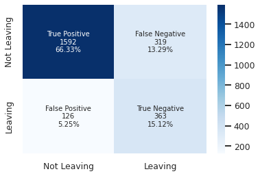

```python
# Setting the prediction threshold
y_pred = model_0.predict(x_val)
y_pred = (y_pred > thresholds0[ix])
#Calculating the confusion matrix
cm=confusion_matrix(y_val, y_pred)
labels = ['True Positive','False Negative','False Positive','True Negative']
categories = [ 'Not Leaving','Leaving']
make_confusion_matrix(cm,
                      group_names=labels,
                      categories=categories,
                      cmap='Blues')
print('Validation Data Confusion Matrix (Optimal Threshold):')
```

```python
# Viewing the validation classification report
cr=metrics.classification_report(y_val,y_pred)
print('Validation Data Classification Report (Optimal Threshold)')
print(cr)
```

```
Validation Data Classification Report (Optimal Threshold)
              precision    recall  f1-score   support

           0       0.93      0.83      0.88      1911
           1       0.53      0.74      0.62       489

    accuracy                           0.81      2400
   macro avg       0.73      0.79      0.75      2400
weighted avg       0.85      0.81      0.82      2400
```

We can see that just by finding the optimal threshold, we have increased our recall score a substantial amount (about 25%) in both the training and validation data sets. Lets see if we can improve upon this by using BayseianOptimization to find the optimal parameters.